# Experiments 1-3 combined

Kenny Smith and Jennifer Culbertson

09/08/2020

# Introduction

Combined analysis of Experiments 1-3.

# Load the data.

```r
#load exp1 data
exp1Data <- read.csv('../RawData/exp1Data.csv')
exp2Data <- read.csv('../RawData/exp2Data.csv')
exp3Data <- read.csv('../RawData/exp3Data.csv')

exp1.to.3.data <- rbind(exp1Data, exp2Data, exp3Data)

#dset everything to factors
exp1.to.3.data$Day <- as.factor(exp1.to.3.data$Day)
exp1.to.3.data$Experiment<-as.factor(exp1.to.3.data$Experiment)
exp1.to.3.data$Animacy <- as.factor(exp1.to.3.data$Animacy)
exp1.to.3.data$ProportionMarked <- as.factor(exp1.to.3.data$ProportionMarked)
#force 40% as reference level
exp1.to.3.data$ProportionMarked <- relevel(exp1.to.3.data$ProportionMarked,ref="40% Casemarked")
#force OSV as reference level
exp1.to.3.data$MajorityInputOrder <- as.factor(exp1.to.3.data$MajorityInputOrder)
exp1.to.3.data$MajorityInputOrder <- relevel(exp1.to.3.data$MajorityInputOrder,ref="OSV majority order")
exp1.to.3.data$OrderMarkedMore <- as.factor(exp1.to.3.data$OrderMarkedMore)
exp1.to.3.data$OrderMarkedMore <- relevel(exp1.to.3.data$OrderMarkedMore,ref="OSV marked more")


#at some point we switched terminology in the paper from Agents Can/Cannot be Patients to Subjects Can/Cannot Be Objects - need to correct this throughout
exp1.to.3.data$EventType <- revalue(exp1.to.3.data$EventType,
                              c("Agents Cannot Be Patients"="Subjects Cannot Be Objects",
                                "Agents Can Be Patients"="Subjects Can Be Objects"))

#Subjects Cannot Be Objects needs to be reference level
exp1.to.3.data$EventType <- as.factor(exp1.to.3.data$EventType)
exp1.to.3.data$EventType <- relevel(exp1.to.3.data$EventType,
                                        ref="Subjects Cannot Be Objects")
```

# Counts of participants and participant exclusions per day

```r
#got this from https://stackoverflow.com/questions/12840294/counting-unique-distinct-values-by-group-in-a-data-frame
exp1.to.3.counts.table <- ddply(exp1.to.3.data,~Day,summarise,N=length(unique(workerId)))
exp1.to.3.counts.table
```

```
##   Day   N
## 1   1 522
## 2   2 404
## 3   3 375
## 4   4 341
```

```r
exp1.to.3.scores.by.block <- aggregate(score~workerId+Day+Block,data=exp1.to.3.data,FUN=mean)
exp1.to.3.failed.noun.comprehension <- subset(exp1.to.3.scores.by.block,Block=='NounComprehension2' & score<0.7)
exp1.to.3.failed.sentence.comprehension <- subset(exp1.to.3.scores.by.block,Block=='SentenceComprehension1' & score<0.7)
ddply(exp1.to.3.failed.sentence.comprehension,~Day,summarise,N_excluded=length(unique(workerId)))
```

```
##   Day N_excluded
## 1   1         25
## 2   2          2
## 3   3          2
```

# Word order and animacy

Want to check for more frequent use of SOV with inanimate objects (= higher use of OSV with animate objects).

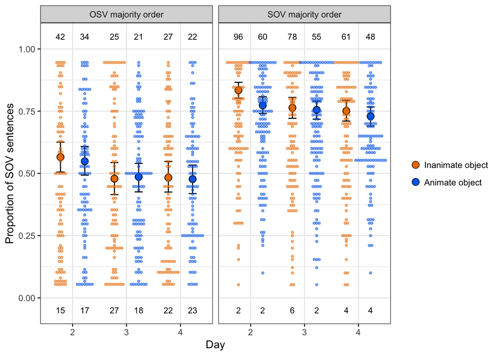

```r
exp1.to.3.sov.summary.by.animacy.collapsed <- aggregate(isSOV~Animacy+Day+MajorityInputOrder+workerId,data=subset(exp1.to.3.data,Block=="SentenceTest1" & grammatical),FUN=mean)

#There are a lot of participants at extreme values in *both* directions here, so need to add text annotations at both ends of the plot.
exp1.to.3.sov.summary.by.animacy.collapsed$IsCeiling <- ifelse(exp1.to.3.sov.summary.by.animacy.collapsed$isSOV==1,1,0)
exp1.to.3.sov.summary.by.animacy.collapsed$IsFloor <- ifelse(exp1.to.3.sov.summary.by.animacy.collapsed$isSOV==0,1,0)

exp1.to.3.sov.summary.by.animacy.collapsed$Day <- droplevels(exp1.to.3.sov.summary.by.animacy.collapsed$Day)

exp1.to.3.allsov.ceiling.ns.collapsed <- data.frame(summarize(group_by(subset(exp1.to.3.sov.summary.by.animacy.collapsed,IsCeiling==1 & Day!=1),Day,Animacy,MajorityInputOrder,.drop = FALSE),n()))
exp1.to.3.allsov.floor.ns.collapsed <- data.frame(summarize(group_by(subset(exp1.to.3.sov.summary.by.animacy.collapsed,IsFloor==1 & Day!=1),Day,Animacy,MajorityInputOrder,.drop = FALSE),n()))
exp1.to.3.allsov.ceiling.ns.collapsed <- plyr::rename(exp1.to.3.allsov.ceiling.ns.collapsed,c("n.."="count"))
exp1.to.3.allsov.floor.ns.collapsed <- plyr::rename(exp1.to.3.allsov.floor.ns.collapsed,c("n.."="count"))

ggplot(data=exp1.to.3.sov.summary.by.animacy.collapsed, aes(x=Day, y=isSOV, fill=Animacy, colour=Animacy)) +
  facet_grid(.~MajorityInputOrder) +
  #points and CIs for word order by animacy
  stat_summary(geom='errorbar', fun.data='mean_cl_boot',fun.ymin="min", fun.ymax="max",width=0.3,position=position_dodge(0.9),color='black') +
  stat_summary(geom='point', fun.y='mean', position=position_dodge(0.9), size=3) +
  stat_summary(geom='point', fun.y='mean', position=position_dodge(0.9), size=3, shape=1, colour='black') +

  #by-participant data
  geom_dotplot(data=subset(exp1.to.3.sov.summary.by.animacy.collapsed,IsCeiling!=1 & IsFloor!=1),aes(x=Day, y=isSOV, shape=Animacy),binaxis = "y", stackdir = "center",alpha=0.5,dotsize=1,position=position_dodge(0.9),binpositions='all',binwidth=1/100) +
  geom_text(data=exp1.to.3.allsov.ceiling.ns.collapsed,aes(x=Day,y=1.05,label=count),position=position_dodge(0.9),size=3,colour='black') +
  geom_text(data=exp1.to.3.allsov.floor.ns.collapsed,aes(x=Day,y=-0.05,label=count),position=position_dodge(0.9),size=3,colour='black') +

  #then various axis/legend stuff
  xlab("Day") +
  theme_bw() +
  ylab("Proportion of SOV sentences") +
  theme(legend.title=element_blank()) +
  scale_colour_manual(values=my.colours[2:3],breaks=c("FALSE", "TRUE"),labels=c("Inanimate object", "Animate object")) +
  scale_fill_manual(values=my.colours[2:3],breaks=c("FALSE", "TRUE"),labels=c("Inanimate object", "Animate object")) +
  ggsave("../Figures/exp1to3-wordorder-collapsed.pdf",width=9, height=9)
```

```r
contrasts(exp1.to.3.data$Animacy) <- c(-0.5,0.5)
contrasts(exp1.to.3.data$ProportionMarked) <- c(-0.5,0.5)
contrasts(exp1.to.3.data$MajorityInputOrder) <- c(-0.5,0.5)

exp1.to.3.sovorder.model.1 <- glmer(isSOV ~ Animacy * Day * ProportionMarked * MajorityInputOrder + (1 + Animacy * Day | workerId),data=subset(exp1.to.3.data,Block=="SentenceTest1" & grammatical),family=binomial,control=glmerControl(optimizer="bobyqa",optCtrl=list(maxfun=50000)))
```

Clear effect of animacy on word order at day 2, marginal interactions suggests this might be lower on days 3–4. Also see a drop in use of SOV over days, as participants learn to use (less preferred) OSV.

```r
summary(exp1.to.3.sovorder.model.1)
```

```
## Generalized linear mixed model fit by maximum likelihood (Laplace Approximation) ['glmerMod']
##  Family: binomial  ( logit )
## Formula: isSOV ~ Animacy * Day * ProportionMarked * MajorityInputOrder +      (1 + Animacy * Day | workerId)
##    Data: subset(exp1.to.3.data, Block == "SentenceTest1" & grammatical)
## Control: glmerControl(optimizer = "bobyqa", optCtrl = list(maxfun = 50000))
##
##      AIC      BIC   logLik deviance df.resid
##  28628.4  29008.7 -14269.2  28538.4    34585
##
## Scaled residuals:
##     Min      1Q  Median      3Q     Max
## -8.3490 -0.3750  0.1085  0.4776  7.5906
##
## Random effects:
##  Groups   Name          Variance Std.Dev. Corr
##  workerId (Intercept)   7.026    2.651
##           Animacy1      1.780    1.334    -0.55
##           Day3          2.978    1.726    -0.22  0.31
##           Day4          4.204    2.050    -0.32  0.28  0.73
##           Animacy1:Day3 1.570    1.253    -0.13 -0.23 -0.64 -0.32
##           Animacy1:Day4 1.467    1.211     0.10 -0.29 -0.46 -0.55  0.72
## Number of obs: 34630, groups:  workerId, 362
##
## Fixed effects:
##                                                      Estimate Std. Error z value Pr(>|z|)
## (Intercept)                                          1.689295   0.153461  11.008  < 2e-16 ***
## Animacy1                                            -0.723233   0.118859  -6.085 1.17e-09 ***
## Day3                                                -0.473285   0.120723  -3.920 8.84e-05 ***
## Day4                                                -0.598747   0.138272  -4.330 1.49e-05 ***
## ProportionMarked1                                    0.124816   0.300312   0.416   0.6777
## MajorityInputOrder1                                  2.145643   0.301488   7.117 1.10e-12 ***
## Animacy1:Day3                                        0.256643   0.139185   1.844   0.0652 .
## Animacy1:Day4                                        0.246299   0.139215   1.769   0.0769 .
## Animacy1:ProportionMarked1                           0.057211   0.200823   0.285   0.7757
## Day3:ProportionMarked1                              -0.176418   0.227910  -0.774   0.4389
## Day4:ProportionMarked1                               0.122056   0.264539   0.461   0.6445
## Animacy1:MajorityInputOrder1                        -0.856724   0.208910  -4.101 4.11e-05 ***
## Day3:MajorityInputOrder1                             0.369642   0.232893   1.587   0.1125
## Day4:MajorityInputOrder1                             0.027505   0.267590   0.103   0.9181
## ProportionMarked1:MajorityInputOrder1               -1.501334   0.585465  -2.564   0.0103 *
## Animacy1:Day3:ProportionMarked1                      0.206516   0.230168   0.897   0.3696
## Animacy1:Day4:ProportionMarked1                      0.007773   0.230948   0.034   0.9732
## Animacy1:Day3:MajorityInputOrder1                   -0.055165   0.250826  -0.220   0.8259
## Animacy1:Day4:MajorityInputOrder1                    0.272286   0.245760   1.108   0.2679
## Animacy1:ProportionMarked1:MajorityInputOrder1       0.284997   0.397455   0.717   0.4733
## Day3:ProportionMarked1:MajorityInputOrder1           0.254612   0.448968   0.567   0.5706
## Day4:ProportionMarked1:MajorityInputOrder1           0.894637   0.521808   1.714   0.0864 .
## Animacy1:Day3:ProportionMarked1:MajorityInputOrder1  0.320815   0.456961   0.702   0.4826
## Animacy1:Day4:ProportionMarked1:MajorityInputOrder1 -0.109585   0.454670  -0.241   0.8095
## ---
## Signif. codes:  0 '***' 0.001 '**' 0.01 '*' 0.05 '.' 0.1 ' ' 1
```

```
##
## Correlation matrix not shown by default, as p = 24 > 12.
## Use print(x, correlation=TRUE)  or
##     vcov(x)        if you need it
```

# Case marking and animacy

Check for the overall pattern of results - any hint of a DOM effect?

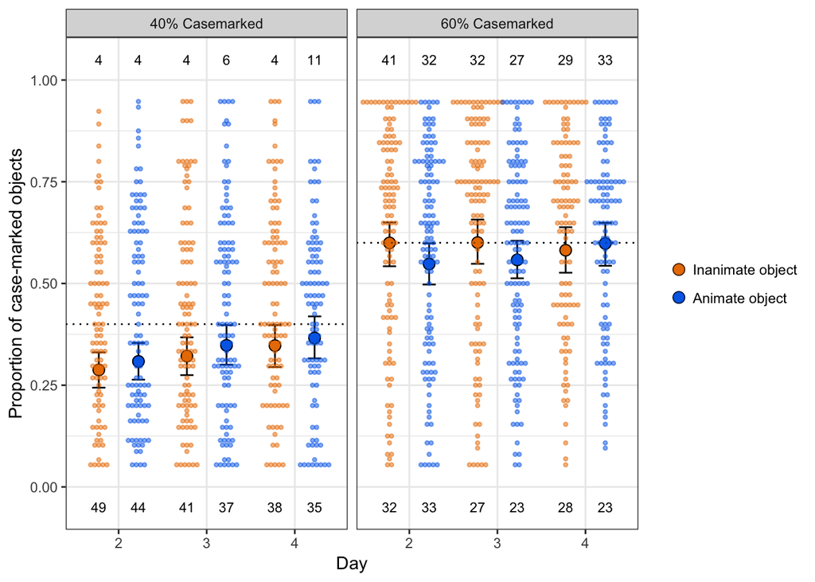

```r
exp1.to.3.casemarking.summary.by.animacy <- aggregate(casemarked~Animacy+Day+ProportionMarked+workerId,data=subset(exp1.to.3.data,Block=="SentenceTest1" & grammatical),FUN=mean)

#There are a lot of participants at extreme values in *both* directions here, so need to add text annotations at both ends of the plot.
exp1.to.3.casemarking.summary.by.animacy$IsCeiling <- ifelse(exp1.to.3.casemarking.summary.by.animacy$casemarked==1,1,0)
exp1.to.3.casemarking.summary.by.animacy$IsFloor <- ifelse(exp1.to.3.casemarking.summary.by.animacy$casemarked==0,1,0)

exp1.to.3.casemarking.summary.by.animacy$Day <- droplevels(exp1.to.3.casemarking.summary.by.animacy$Day)

exp1.to.3.casemarking.ceiling.ns.collapsed <- data.frame(summarize(group_by(subset(exp1.to.3.casemarking.summary.by.animacy,IsCeiling==1 & Day!=1),Day,Animacy,ProportionMarked,.drop = FALSE),n()))
exp1.to.3.casemarking.floor.ns.collapsed <- data.frame(summarize(group_by(subset(exp1.to.3.casemarking.summary.by.animacy,IsFloor==1 & Day!=1),Day,Animacy,ProportionMarked,.drop = FALSE),n()))
exp1.to.3.casemarking.ceiling.ns.collapsed <- plyr::rename(exp1.to.3.casemarking.ceiling.ns.collapsed,c("n.."="count"))
exp1.to.3.casemarking.floor.ns.collapsed <- plyr::rename(exp1.to.3.casemarking.floor.ns.collapsed,c("n.."="count"))

#need to specify input split by ProportionMarked
exp1.to.3.inputs <- data.frame(Day=rep(c(1,2,3),2),
                               ProportionMarked=rep(c("40% Casemarked","60% Casemarked"),each=3),
                               casemarked=rep(c(2/5,3/5),each=3))



ggplot(data=exp1.to.3.casemarking.summary.by.animacy, aes(x=Day, y=casemarked,
                                                     colour=Animacy,fill=Animacy)) +
  facet_grid(.~ProportionMarked) +
  #bars and CIs for casemarking by animacy
  stat_summary(geom='errorbar', fun.data='mean_cl_boot',fun.ymin="min", fun.ymax="max",width=0.3,position=position_dodge(0.9),colour='black') +
  stat_summary(geom='point',fun.y='mean', position=position_dodge(0.9),size=3) +
  stat_summary(geom='point',fun.y='mean', position=position_dodge(0.9),size=3,shape=1,colour='black') +

  #horizontal lines showing input
 geom_hline(dat=exp1.to.3.inputs,aes(yintercept=casemarked),linetype=3) +

  #by-participant data
  geom_dotplot(data=subset(exp1.to.3.casemarking.summary.by.animacy,IsCeiling!=1 & IsFloor!=1),aes(x=Day, y=casemarked, shape=Animacy),binaxis = "y", stackdir = "center",alpha=0.5,dotsize=1,position=position_dodge(0.9),binpositions='all',binwidth=1/100) +
  geom_text(data=exp1.to.3.casemarking.ceiling.ns.collapsed,aes(x=Day,y=1.05,label=count),position=position_dodge(0.9),size=3,colour='black') +
  geom_text(data=exp1.to.3.casemarking.floor.ns.collapsed,aes(x=Day,y=-0.05,label=count),position=position_dodge(0.9),size=3,colour='black') +

  #geom_point(aes(x=Day, y=casemarked, shape=Animacy),alpha=0.2,dotsize=1,position=position_jitterdodge(jitter.width= 0.2, jitter.height = 0,dodge.width = 0.9),fill='black') +
  #force all points to be circles, and exclude from legend
  scale_shape_manual(values=c(21,21),guide=FALSE)+
  #then various axis/legend stuff
  xlab("Day") +
  theme_bw() +
  ylab("Proportion of case-marked objects") +
  theme(legend.title=element_blank()) +
  scale_fill_manual(values=my.colours[2:3],breaks=c("FALSE", "TRUE"),labels=c("Inanimate object", "Animate object")) +
  scale_colour_manual(values=my.colours[2:3],breaks=c("FALSE", "TRUE"),labels=c("Inanimate object", "Animate object")) +
  ggsave("../Figures/exp1to3-casemarking.pdf",width=9, height=6)
```

```r
exp1.to.3.data$Animacy <- factor(exp1.to.3.data$Animacy)
contrasts(exp1.to.3.data$Animacy) <- c(-0.5,0.5)
contrasts(exp1.to.3.data$EventType) <- c(-0.5,0.5)
contrasts(exp1.to.3.data$ProportionMarked) <- c(-0.5,0.5)
contrasts(exp1.to.3.data$MajorityInputOrder) <- c(-0.5,0.5)
contrasts(exp1.to.3.data$OrderMarkedMore) <- c(-0.5,0.5)

exp1.to.3.case.marking.model.1 <- glmer(casemarked ~ Animacy * ProportionMarked * OrderMarkedMore * EventType* Day + (1 + Animacy * Day | workerId),data=subset(exp1.to.3.data,Block=="SentenceTest1" & grammatical),family=binomial,control=glmerControl(optimizer="bobyqa",optCtrl=list(maxfun=50000)))
```

Day 2 shows no overall effect of animacy but the animacy * proportion interaction predicted under typicality alignment, which significantly reverses by day 4. Nothing else that is anywhere near significant involves animacy.

```r
summary(exp1.to.3.case.marking.model.1)
```

```
## Generalized linear mixed model fit by maximum likelihood (Laplace Approximation) ['glmerMod']
##  Family: binomial  ( logit )
## Formula: casemarked ~ Animacy * ProportionMarked * OrderMarkedMore * EventType *      Day + (1 + Animacy * Day | workerId)
##    Data: subset(exp1.to.3.data, Block == "SentenceTest1" & grammatical)
## Control: glmerControl(optimizer = "bobyqa", optCtrl = list(maxfun = 50000))
##
##      AIC      BIC   logLik deviance df.resid
##  30751.9  31335.2 -15307.0  30613.9    34561
##
## Scaled residuals:
##     Min      1Q  Median      3Q     Max
## -6.5527 -0.4829 -0.0705  0.5268  6.4305
##
## Random effects:
##  Groups   Name          Variance Std.Dev. Corr
##  workerId (Intercept)   7.013    2.648
##           Animacy1      2.385    1.544    -0.10
##           Day3          2.416    1.554    -0.32  0.10
##           Day4          3.736    1.933    -0.32 -0.02  0.80
##           Animacy1:Day3 1.921    1.386    -0.02 -0.39 -0.18 -0.06
##           Animacy1:Day4 1.753    1.324     0.13 -0.40 -0.07  0.02  0.88
## Number of obs: 34630, groups:  workerId, 362
##
## Fixed effects:
##                                                             Estimate Std. Error z value Pr(>|z|)
## (Intercept)                                                 -0.72441    0.14958  -4.843 1.28e-06 ***
## Animacy1                                                    -0.07221    0.11306  -0.639  0.52306
## ProportionMarked1                                            2.18644    0.29773   7.344 2.08e-13 ***
## OrderMarkedMore1                                             0.16564    0.29660   0.558  0.57653
## EventType1                                                  -0.03920    0.29639  -0.132  0.89479
## Day3                                                         0.21161    0.10435   2.028  0.04258 *
## Day4                                                         0.29820    0.12579   2.371  0.01776 *
## Animacy1:ProportionMarked1                                  -0.62643    0.22410  -2.795  0.00518 **
## Animacy1:OrderMarkedMore1                                   -0.12702    0.21663  -0.586  0.55763
## ProportionMarked1:OrderMarkedMore1                           0.10504    0.57933   0.181  0.85612
## Animacy1:EventType1                                         -0.31261    0.21673  -1.442  0.14919
## ProportionMarked1:EventType1                                 1.30385    0.57960   2.250  0.02448 *
## OrderMarkedMore1:EventType1                                 -1.15951    0.57804  -2.006  0.04487 *
## Animacy1:Day3                                                0.04649    0.12429   0.374  0.70838
## Animacy1:Day4                                                0.14035    0.12437   1.128  0.25913
```

[output cut: 20 more lines]

```
## OrderMarkedMore1:EventType1:Day3                             0.39226    0.40046   0.980  0.32733
## OrderMarkedMore1:EventType1:Day4                            -0.01324    0.48386  -0.027  0.97816
## Animacy1:ProportionMarked1:OrderMarkedMore1:EventType1       1.41274    0.81231   1.739  0.08201 .
## Animacy1:ProportionMarked1:OrderMarkedMore1:Day3             0.37426    0.46303   0.808  0.41893
## Animacy1:ProportionMarked1:OrderMarkedMore1:Day4             0.76159    0.46264   1.646  0.09972 .
## Animacy1:ProportionMarked1:EventType1:Day3                   0.51026    0.46576   1.096  0.27329
## Animacy1:ProportionMarked1:EventType1:Day4                   0.23278    0.46396   0.502  0.61585
## Animacy1:OrderMarkedMore1:EventType1:Day3                   -0.48116    0.46674  -1.031  0.30260
## Animacy1:OrderMarkedMore1:EventType1:Day4                    0.06292    0.46677   0.135  0.89277
## ProportionMarked1:OrderMarkedMore1:EventType1:Day3           0.72365    0.76473   0.946  0.34400
## ProportionMarked1:OrderMarkedMore1:EventType1:Day4           1.71822    0.92300   1.862  0.06266 .
## Animacy1:ProportionMarked1:OrderMarkedMore1:EventType1:Day3 -1.30253    0.86837  -1.500  0.13362
## Animacy1:ProportionMarked1:OrderMarkedMore1:EventType1:Day4 -1.01579    0.88405  -1.149  0.25055
## ---
## Signif. codes:  0 '***' 0.001 '**' 0.01 '*' 0.05 '.' 0.1 ' ' 1
```

```
##
## Correlation matrix not shown by default, as p = 48 > 12.
## Use print(x, correlation=TRUE)  or
##     vcov(x)        if you need it
```

Model comparison, +/- the interaction between animacy and proportion?

```r
comparison.model.a <- glmer(casemarked ~ (Animacy + ProportionMarked) * Day + (1 + Animacy * Day | workerId),data=subset(exp1.to.3.data,Block=="SentenceTest1" & grammatical),family=binomial,control=glmerControl(optimizer="bobyqa",optCtrl=list(maxfun=50000)))

comparison.model.b <- glmer(casemarked ~ Animacy * ProportionMarked * Day + (1 + Animacy * Day | workerId),data=subset(exp1.to.3.data,Block=="SentenceTest1" & grammatical),family=binomial,control=glmerControl(optimizer="bobyqa",optCtrl=list(maxfun=50000)))
```

The model with the interaction is a significiantly better fit.

```r
anova(comparison.model.a,comparison.model.b)
```

```
## Data: subset(exp1.to.3.data, Block == "SentenceTest1" & grammatical)
## Models:
## comparison.model.a: casemarked ~ (Animacy + ProportionMarked) * Day + (1 + Animacy *
## comparison.model.a:     Day | workerId)
## comparison.model.b: casemarked ~ Animacy * ProportionMarked * Day + (1 + Animacy *
## comparison.model.b:     Day | workerId)
##                    Df   AIC   BIC logLik deviance  Chisq Chi Df Pr(>Chisq)
## comparison.model.a 30 30727 30981 -15334    30667
## comparison.model.b 33 30718 30997 -15326    30652 14.926      3   0.001881 **
## ---
## Signif. codes:  0 '***' 0.001 '**' 0.01 '*' 0.05 '.' 0.1 ' ' 1
```

Model controlling for word order.

```r
contrasts(exp1.to.3.data$WordOrder) <- c(-0.5,0.5)

exp1.to.3.case.marking.model.3 <- glmer(casemarked ~ Animacy * Day * ProportionMarked * OrderMarkedMore
                                        * (EventType + WordOrder)
                                   + (1  | workerId)
                                   + (0 + Animacy + Day + WordOrder | workerId),
                                   data=subset(exp1.to.3.data,Block=="SentenceTest1" & grammatical),
                                   family=binomial,control=glmerControl(optimizer="bobyqa",optCtrl=list(maxfun=100000)))
```

```r
summary(exp1.to.3.case.marking.model.3)
```

```
## Generalized linear mixed model fit by maximum likelihood (Laplace Approximation) ['glmerMod']
##  Family: binomial  ( logit )
## Formula: casemarked ~ Animacy * Day * ProportionMarked * OrderMarkedMore *      (EventType + WordOrder) + (1 | workerId) + (0 + Animacy +      Day + WordOrder | workerId)
##    Data: subset(exp1.to.3.data, Block == "SentenceTest1" & grammatical)
## Control: glmerControl(optimizer = "bobyqa", optCtrl = list(maxfun = 1e+05))
##
##      AIC      BIC   logLik deviance df.resid
##  29258.3  30002.1 -14541.2  29082.3    34542
##
## Scaled residuals:
##     Min      1Q  Median      3Q     Max
## -8.4749 -0.4319 -0.0615  0.4533 10.1064
##
## Random effects:
##  Groups     Name         Variance Std.Dev. Corr
##  workerId   (Intercept)  4.056    2.014
##  workerId.1 AnimacyFALSE 4.044    2.011
##             AnimacyTRUE  4.081    2.020     0.73
##             Day3         2.825    1.681    -0.58 -0.60
##             Day4         4.412    2.100    -0.55 -0.61  0.83
##             WordOrder1   2.562    1.601    -0.06 -0.09  0.26  0.26
## Number of obs: 34630, groups:  workerId, 362
##
## Fixed effects:
##                                                              Estimate Std. Error z value Pr(>|z|)
## (Intercept)                                                 -0.520166   0.158371  -3.284 0.001022 **
## Animacy1                                                    -0.215529   0.108230  -1.991 0.046437 *
## Day3                                                         0.214034   0.113435   1.887 0.059181 .
## Day4                                                         0.286984   0.136642   2.100 0.035706 *
## ProportionMarked1                                            1.875009   0.314773   5.957 2.57e-09 ***
## OrderMarkedMore1                                            -0.371236   0.313558  -1.184 0.236434
## EventType1                                                  -0.021337   0.310453  -0.069 0.945206
## WordOrder1                                                  -0.871758   0.128425  -6.788 1.14e-11 ***
## Animacy1:Day3                                                0.049770   0.088875   0.560 0.575476
## Animacy1:Day4                                                0.208512   0.091381   2.282 0.022501 *
## Animacy1:ProportionMarked1                                  -0.478265   0.215898  -2.215 0.026744 *
## Day3:ProportionMarked1                                      -0.357701   0.225073  -1.589 0.111999
## Day4:ProportionMarked1                                      -0.130074   0.272297  -0.478 0.632868
## Animacy1:OrderMarkedMore1                                   -0.134105   0.214551  -0.625 0.531937
## Day3:OrderMarkedMore1                                        0.412814   0.223221   1.849 0.064407 .
```

[output cut: 44 more lines]

```
## Animacy1:Day4:OrderMarkedMore1:EventType1                    0.017558   0.335846   0.052 0.958305
## Animacy1:Day3:OrderMarkedMore1:WordOrder1                    1.013391   0.351653   2.882 0.003954 **
## Animacy1:Day4:OrderMarkedMore1:WordOrder1                    0.397479   0.357867   1.111 0.266701
## Animacy1:ProportionMarked1:OrderMarkedMore1:EventType1       1.798294   0.782864   2.297 0.021615 *
## Animacy1:ProportionMarked1:OrderMarkedMore1:WordOrder1      -0.155333   0.524471  -0.296 0.767100
## Day3:ProportionMarked1:OrderMarkedMore1:EventType1           0.954994   0.807579   1.183 0.236992
## Day4:ProportionMarked1:OrderMarkedMore1:EventType1           1.896629   0.976397   1.942 0.052079 .
## Day3:ProportionMarked1:OrderMarkedMore1:WordOrder1          -0.147385   0.418986  -0.352 0.725014
## Day4:ProportionMarked1:OrderMarkedMore1:WordOrder1           0.097477   0.440608   0.221 0.824912
## Animacy1:Day3:ProportionMarked1:OrderMarkedMore1:EventType1 -1.586553   0.633006  -2.506 0.012198 *
## Animacy1:Day4:ProportionMarked1:OrderMarkedMore1:EventType1 -1.906805   0.662276  -2.879 0.003987 **
## Animacy1:Day3:ProportionMarked1:OrderMarkedMore1:WordOrder1  0.820213   0.679256   1.208 0.227233
## Animacy1:Day4:ProportionMarked1:OrderMarkedMore1:WordOrder1  0.220546   0.686822   0.321 0.748127
## ---
## Signif. codes:  0 '***' 0.001 '**' 0.01 '*' 0.05 '.' 0.1 ' ' 1
```

```
##
## Correlation matrix not shown by default, as p = 72 > 12.
## Use print(x, correlation=TRUE)  or
##     vcov(x)        if you need it
```

```
## convergence code: 0
## Model failed to converge with max|grad| = 0.00109718 (tol = 0.001, component 1)
```

```r
car::vif(exp1.to.3.case.marking.model.3)
```

```
##                                                            GVIF Df GVIF^(1/(2*Df))
## Animacy                                                1.458104  1        1.207520
## Day                                                    1.213928  2        1.049659
## ProportionMarked                                       1.350967  1        1.162311
## OrderMarkedMore                                        1.350430  1        1.162080
## EventType                                              1.323369  1        1.150378
## WordOrder                                              1.478716  1        1.216024
## Animacy:Day                                            1.870149  2        1.169416
## Animacy:ProportionMarked                               1.454046  1        1.205838
## Day:ProportionMarked                                   1.552355  2        1.116215
## Animacy:OrderMarkedMore                                1.459591  1        1.208135
## Day:OrderMarkedMore                                    1.552469  2        1.116235
## ProportionMarked:OrderMarkedMore                       1.302341  1        1.141202
## Animacy:EventType                                      1.342566  1        1.158691
## Animacy:WordOrder                                      2.950365  1        1.717663
## Day:EventType                                          1.373330  2        1.082539
## Day:WordOrder                                          1.546398  2        1.115142
## ProportionMarked:EventType                             1.284827  1        1.133502
## ProportionMarked:WordOrder                             1.469532  1        1.212243
## OrderMarkedMore:EventType                              1.286000  1        1.134020
## OrderMarkedMore:WordOrder                              1.473498  1        1.213877
## Animacy:Day:ProportionMarked                           1.867291  2        1.168969
## Animacy:Day:OrderMarkedMore                            1.879342  2        1.170851
## Animacy:ProportionMarked:OrderMarkedMore               1.434919  1        1.197881
## Day:ProportionMarked:OrderMarkedMore                   1.501868  2        1.107026
## Animacy:Day:EventType                                  1.423071  2        1.092211
## Animacy:Day:WordOrder                                  3.554084  2        1.373036
## Animacy:ProportionMarked:EventType                     1.329810  1        1.153174
## Animacy:ProportionMarked:WordOrder                     2.897341  1        1.702158
## Day:ProportionMarked:EventType                         1.341041  2        1.076119
## Day:ProportionMarked:WordOrder                         1.536384  2        1.113333
## Animacy:OrderMarkedMore:EventType                      1.331805  1        1.154039
## Animacy:OrderMarkedMore:WordOrder                      2.887826  1        1.699361
## Day:OrderMarkedMore:EventType                          1.344121  2        1.076737
## Day:OrderMarkedMore:WordOrder                          1.530611  2        1.112285
## ProportionMarked:OrderMarkedMore:EventType             1.258996  1        1.122050
## ProportionMarked:OrderMarkedMore:WordOrder             1.442274  1        1.200947
## Animacy:Day:ProportionMarked:OrderMarkedMore           1.842089  2        1.165005
## Animacy:Day:ProportionMarked:EventType                 1.408108  2        1.089329
## Animacy:Day:ProportionMarked:WordOrder                 3.484802  2        1.366295
## Animacy:Day:OrderMarkedMore:EventType                  1.409993  2        1.089693
## Animacy:Day:OrderMarkedMore:WordOrder                  3.468099  2        1.364655
## Animacy:ProportionMarked:OrderMarkedMore:EventType     1.305387  1        1.142535
## Animacy:ProportionMarked:OrderMarkedMore:WordOrder     2.731376  1        1.652687
## Day:ProportionMarked:OrderMarkedMore:EventType         1.316551  2        1.071172
## Day:ProportionMarked:OrderMarkedMore:WordOrder         1.518058  2        1.109998
## Animacy:Day:ProportionMarked:OrderMarkedMore:EventType 1.381675  2        1.084180
## Animacy:Day:ProportionMarked:OrderMarkedMore:WordOrder 3.274251  2        1.345173
```

# Case marking and animacy during interaction

```r
#since there is some data munging here, will set this up as a seperate data frame
exp1.to.3RecallVsInteractionData <- subset(exp1.to.3.data,(Block=="Interaction" | Block=="SentenceTest1") & grammatical & Day==4)
#want recall to be the reference level
exp1.to.3RecallVsInteractionData$Block <- relevel(droplevels(exp1.to.3RecallVsInteractionData$Block),ref="SentenceTest1")

exp1.to.3.recall.vs.interaction.summary <- aggregate(casemarked~Animacy+Block+EventType+ProportionMarked+workerId,data=exp1.to.3RecallVsInteractionData,FUN=mean)

#prettier names for printing
exp1.to.3.recall.vs.interaction.summary$Block <- revalue(exp1.to.3.recall.vs.interaction.summary$Block,
                                         c("SentenceTest1"="Recall",
                                           "Interaction"="Interaction"))
```

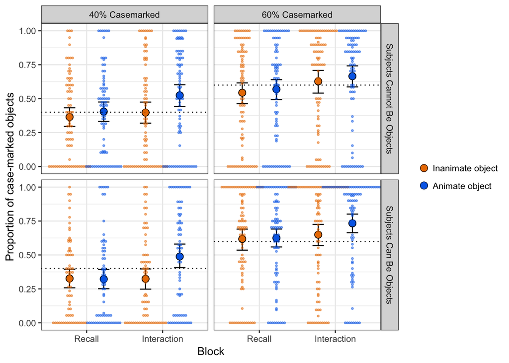

```r
ggplot(data=exp1.to.3.recall.vs.interaction.summary, aes(x=Block, y=casemarked,
                                                    colour=Animacy, fill=Animacy)) +
  facet_grid(EventType~ProportionMarked) +
  #points and CIs for casemarking by animacy
  stat_summary(geom='errorbar', fun.data='mean_cl_boot',fun.ymin="min", fun.ymax="max",width=0.3,position=position_dodge(0.9),color='black') +
  stat_summary(geom='point', fun.y='mean', position=position_dodge(0.9),size=3) +
  stat_summary(geom='point', fun.y='mean', position=position_dodge(0.9),size=3,
               shape=1,colour='black') +

  #horizontal lines showing input
  geom_hline(dat=exp1.to.3.inputs,aes(yintercept=casemarked),linetype=3) +
  #by-participant data
  geom_dotplot(aes(x=Block, y=casemarked, shape=Animacy),binaxis = "y", stackdir = "center",alpha=0.5,dotsize=1.5,position=position_dodge(0.9),binpositions='all',binwidth=1/100) +
  #then various axis/legend stuff
  xlab("Block") +
  theme_bw() +
  ylab("Proportion of case-marked objects") +
  theme(legend.title=element_blank()) +
  scale_colour_manual(values=my.colours[2:3],breaks=c("FALSE", "TRUE"),labels=c("Inanimate object", "Animate object")) +
  scale_fill_manual(values=my.colours[2:3],breaks=c("FALSE", "TRUE"),labels=c("Inanimate object", "Animate object")) +
  ggsave("../Figures/exp1to3-interaction-casemarking.pdf",width=9, height=6)
```

Same plot collapsing over ProportionMarked (since those effects are gone by day 4 anyway).

```r
exp1.to.3.recall.vs.interaction.summary.collapsed <- aggregate(casemarked~Animacy+Block+EventType+workerId,data=exp1.to.3RecallVsInteractionData,FUN=mean)

#prettier names for printing
exp1.to.3.recall.vs.interaction.summary.collapsed$Block <- revalue(exp1.to.3.recall.vs.interaction.summary.collapsed$Block,
                                         c("SentenceTest1"="Recall",
                                           "Interaction"="Interaction"))
```

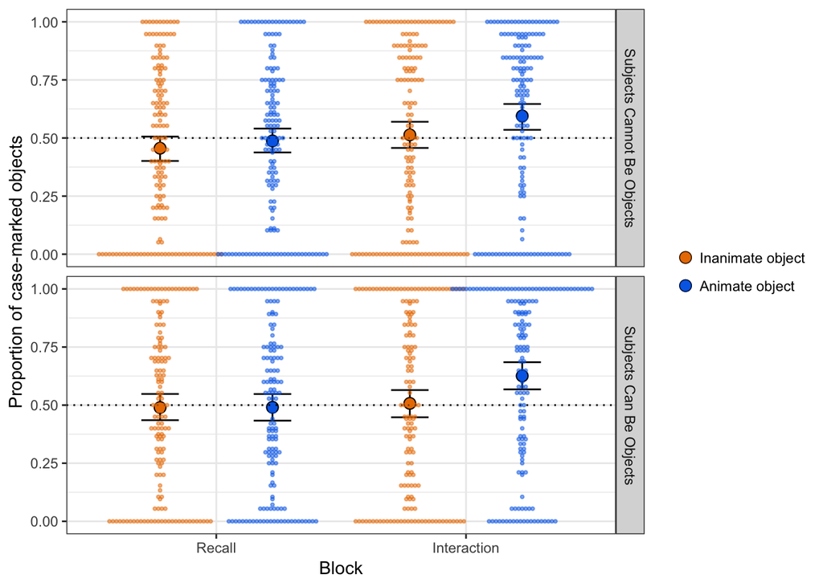

```r
ggplot(data=exp1.to.3.recall.vs.interaction.summary.collapsed, aes(x=Block, y=casemarked,
                                                    colour=Animacy, fill=Animacy)) +
  facet_grid(EventType~.) +
  #points and CIs for casemarking by animacy
  stat_summary(geom='errorbar', fun.data='mean_cl_boot',fun.ymin="min", fun.ymax="max",width=0.3,position=position_dodge(0.9),color='black') +
  stat_summary(geom='point', fun.y='mean', position=position_dodge(0.9),size=3) +
  stat_summary(geom='point', fun.y='mean', position=position_dodge(0.9),size=3,
               shape=1,colour='black') +

  #horizontal lines showing input
  geom_hline(aes(yintercept=0.5),linetype=3) +
  #by-participant data
  geom_dotplot(aes(x=Block, y=casemarked, shape=Animacy),binaxis = "y", stackdir = "center",alpha=0.5,dotsize=1.5,position=position_dodge(0.9),binpositions='all',binwidth=1/100) +
  #then various axis/legend stuff
  xlab("Block") +
  theme_bw() +
  ylab("Proportion of case-marked objects") +
  theme(legend.title=element_blank()) +
  scale_colour_manual(values=my.colours[2:3],breaks=c("FALSE", "TRUE"),labels=c("Inanimate object", "Animate object")) +
  scale_fill_manual(values=my.colours[2:3],breaks=c("FALSE", "TRUE"),labels=c("Inanimate object", "Animate object")) +
  ggsave("../Figures/exp1to3-interaction-casemarking-collapsed.pdf",width=9, height=6)
```

Stat where block is treatment-coded.

```r
exp1.to.3RecallVsInteractionData$Animacy <- factor(exp1.to.3RecallVsInteractionData$Animacy)
contrasts(exp1.to.3RecallVsInteractionData$Animacy) <- c(-0.5,0.5)
contrasts(exp1.to.3RecallVsInteractionData$EventType) <- c(-0.5,0.5)

exp1.to.3.recall.vs.interaction.model.1 <- glmer(casemarked ~ Animacy * Block * EventType + (1 + Animacy *  Block | workerId),data=exp1.to.3RecallVsInteractionData,family=binomial,control=glmerControl(optimizer="bobyqa"))
```

```r
summary(exp1.to.3.recall.vs.interaction.model.1)
```

```
## Generalized linear mixed model fit by maximum likelihood (Laplace Approximation) ['glmerMod']
##  Family: binomial  ( logit )
## Formula: casemarked ~ Animacy * Block * EventType + (1 + Animacy * Block |      workerId)
##    Data: exp1.to.3RecallVsInteractionData
## Control: glmerControl(optimizer = "bobyqa")
##
##      AIC      BIC   logLik deviance df.resid
##  19427.8  19572.6  -9695.9  19391.8    23007
##
## Scaled residuals:
##     Min      1Q  Median      3Q     Max
## -6.2100 -0.3916  0.0677  0.4725  5.3806
##
## Random effects:
##  Groups   Name                      Variance Std.Dev. Corr
##  workerId (Intercept)               8.815    2.969
##           Animacy1                  2.559    1.600     0.00
##           BlockInteraction          2.687    1.639    -0.02 -0.16
##           Animacy1:BlockInteraction 1.098    1.048    -0.40  0.37  0.07
## Number of obs: 23025, groups:  workerId, 314
##
## Fixed effects:
##                                      Estimate Std. Error z value Pr(>|z|)
## (Intercept)                           -0.3556     0.1730  -2.056   0.0398 *
## Animacy1                               0.1481     0.1124   1.318   0.1876
## BlockInteraction                       0.6586     0.1087   6.056 1.39e-09 ***
## EventType1                             0.3343     0.3452   0.969   0.3328
## Animacy1:BlockInteraction              0.6811     0.1075   6.338 2.32e-10 ***
## Animacy1:EventType1                   -0.2074     0.2213  -0.937   0.3485
## BlockInteraction:EventType1            0.1510     0.2166   0.697   0.4857
## Animacy1:BlockInteraction:EventType1   0.5154     0.2129   2.420   0.0155 *
## ---
## Signif. codes:  0 '***' 0.001 '**' 0.01 '*' 0.05 '.' 0.1 ' ' 1
##
## Correlation of Fixed Effects:
##             (Intr) Anmcy1 BlckIn EvntT1 An1:BI A1:ET1 BI:ET1
## Animacy1     0.006
## BlckIntrctn -0.102 -0.126
## EventType1   0.003  0.002 -0.002
## Anmcy1:BlcI -0.223 -0.106  0.042 -0.004
## Anmcy1:EvT1  0.001 -0.005 -0.003  0.006  0.007
## BlckInt:ET1 -0.001 -0.003  0.009 -0.098  0.015 -0.129
## Anm1:BI:ET1 -0.002  0.012  0.018 -0.227  0.015 -0.083  0.050
```

What does the timecourse of marking look like - do participants realise they need to start marking even in the Subjects Cannot Be Objects condition? Data is quite noisy!

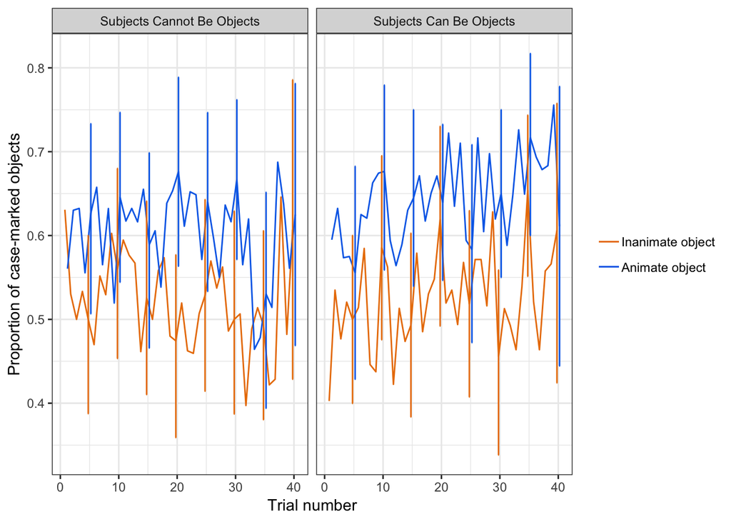

```r
#add by-participant trial counter, setting first direct trial as 1
exp1.to.3interaction.direct.data <- subset(exp1.to.3RecallVsInteractionData,Block=="Interaction")
exp1.to.3interaction.direct.data$trialNumber <- plyr::ddply(exp1.to.3interaction.direct.data, plyr::.(workerId), plyr::mutate, id = seq_along(trialn))$id
exp1.to.3interaction.direct.data$casemarked <- as.numeric(exp1.to.3interaction.direct.data$casemarked)

ggplot(exp1.to.3interaction.direct.data,aes(x=trialNumber,y=casemarked,colour=Animacy)) +
  facet_grid(~EventType) +
  stat_summary(geom='line', fun.y='mean', position=position_dodge(0.9)) +
  stat_summary(data=subset(exp1.to.3interaction.direct.data,(trialNumber)%%5==0),geom='errorbar', fun.data='mean_cl_boot',fun.ymin="min", fun.ymax="max",width=0.3,position=position_dodge(0.9)) +
  #then various axis/legend stuff
  xlab("Trial number") +
  theme_bw() +
  ylab("Proportion of case-marked objects") +
  theme(legend.title=element_blank()) +
  scale_colour_manual(values=my.colours[c(2:3)],breaks=c("FALSE", "TRUE"),labels=c("Inanimate object", "Animate object"))
```

Smoothing the plot by binning by trial number.

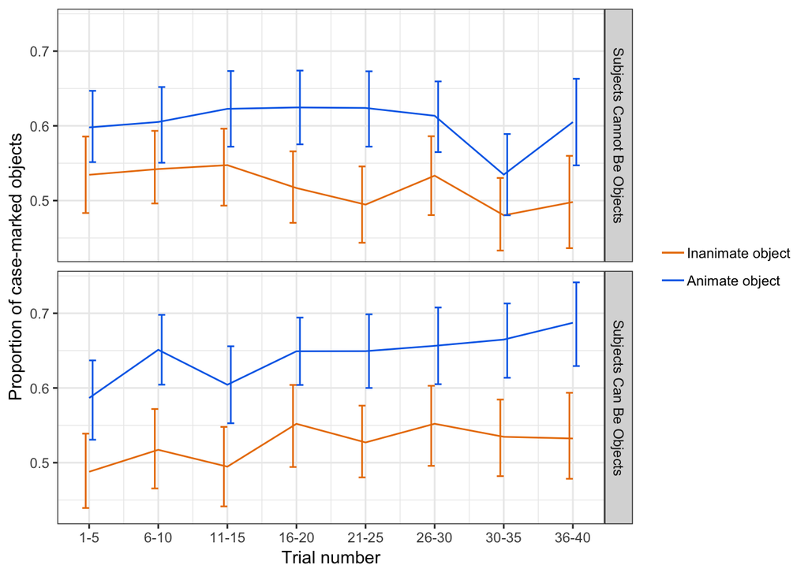

```r
exp1.to.3interaction.direct.data$trialNumberBinned <- (exp1.to.3interaction.direct.data$trialNumber-1) %/% 5
ggplot(exp1.to.3interaction.direct.data,aes(x=trialNumberBinned,y=casemarked,colour=Animacy)) +
  facet_grid(EventType~.) +
  stat_summary(geom='line', fun.y='mean') +
  stat_summary(geom='errorbar', fun.data='mean_cl_boot',fun.ymin="min", fun.ymax="max",width=0.2,position=position_dodge(0.2)) +
  #then various axis/legend stuff
  xlab("Trial number") +
  theme_bw() +
  ylab("Proportion of case-marked objects") +
  theme(legend.title=element_blank()) +
  scale_colour_manual(values=my.colours[c(2:3)],breaks=c("FALSE", "TRUE"),labels=c("Inanimate object", "Animate object")) +
  scale_x_continuous(breaks=0:7,labels=c("1-5","6-10","11-15","16-20","21-25","26-30","30-35","36-40")) +
  ggsave("../Figures/exp1to3-interaction-timecourse.pdf",width=9, height=6)
```

Model with treatment-coding - shows that participants in the SubjectsCannot condition start out by *not* differentiating based on animacy (n.s. effect of animacy), but then increasingly do so (animacy x trialN); in the SubjectsCan condition they differentiate from the start (animacy x SubjectsCan), but don’t increase this over trials (- interaction of animacy x trialN x SubjectsCan).

```r
exp1.to.3interaction.direct.data$trialNumberMinus <- exp1.to.3interaction.direct.data$trialNumber-1
contrasts(exp1.to.3interaction.direct.data$EventType) <- NULL
contrasts(exp1.to.3interaction.direct.data$Animacy) <- c(-0.5,0.5)

exp1.to.3casemarking.timecourse.model.1 <- glmer(casemarked ~ trialNumberMinus*Animacy * EventType + (1 + trialNumberMinus*Animacy | workerId),data=exp1.to.3interaction.direct.data,family=binomial,control=glmerControl(optimizer="bobyqa",optCtrl=list(maxfun=50000)))
summary(exp1.to.3casemarking.timecourse.model.1)
```

```
## Generalized linear mixed model fit by maximum likelihood (Laplace Approximation) ['glmerMod']
##  Family: binomial  ( logit )
## Formula: casemarked ~ trialNumberMinus * Animacy * EventType + (1 + trialNumberMinus *      Animacy | workerId)
##    Data: exp1.to.3interaction.direct.data
## Control: glmerControl(optimizer = "bobyqa", optCtrl = list(maxfun = 50000))
##
##      AIC      BIC   logLik deviance df.resid
##   9386.1   9518.4  -4675.0   9350.1    11530
##
## Scaled residuals:
##     Min      1Q  Median      3Q     Max
## -4.8066 -0.2621  0.1001  0.4158  4.9707
##
## Random effects:
##  Groups   Name                      Variance  Std.Dev. Corr
##  workerId (Intercept)               1.161e+01 3.40805
##           trialNumberMinus          6.333e-04 0.02517  -0.26
##           Animacy1                  3.865e+00 1.96588  -0.13 -0.11
##           trialNumberMinus:Animacy1 9.353e-04 0.03058  -0.54 -0.05  0.14
## Number of obs: 11548, groups:  workerId, 312
##
## Fixed effects:
##                                                             Estimate Std. Error z value Pr(>|z|)
## (Intercept)                                                 0.222475   0.288680   0.771   0.4409
## trialNumberMinus                                           -0.004597   0.004289  -1.072   0.2837
## Animacy1                                                    0.403610   0.231678   1.742   0.0815 .
## EventTypeSubjects Can Be Objects                            0.224290   0.409276   0.548   0.5837
## trialNumberMinus:Animacy1                                   0.014845   0.007717   1.924   0.0544 .
## trialNumberMinus:EventTypeSubjects Can Be Objects           0.012974   0.006146   2.111   0.0348 *
## Animacy1:EventTypeSubjects Can Be Objects                   0.687427   0.332520   2.067   0.0387 *
## trialNumberMinus:Animacy1:EventTypeSubjects Can Be Objects -0.023489   0.011111  -2.114   0.0345 *
## ---
## Signif. codes:  0 '***' 0.001 '**' 0.01 '*' 0.05 '.' 0.1 ' ' 1
##
## Correlation of Fixed Effects:
##             (Intr) trlNmM Anmcy1 ETSCBO tNM:A1 tNM:ECBO A1:CBO
## trilNmbrMns -0.332
## Animacy1    -0.089 -0.021
## EvntTypSCBO -0.705  0.234  0.062
## trlNmbrM:A1 -0.156 -0.061 -0.512  0.109
## trNM:ETSCBO  0.233 -0.699  0.014 -0.336  0.048
## Anm1:ETSCBO  0.063  0.012 -0.698 -0.075  0.356 -0.049
## tNM:A1:ECBO  0.107  0.050  0.358 -0.165 -0.697 -0.022   -0.522
## convergence code: 0
## Model failed to converge with max|grad| = 0.001477 (tol = 0.001, component 1)
```

# Word order variability and casemarking

## Word order variability and DOM

Do participants who vary word order more (i.e. word order is less informative about argument structure) differentiate more?

Measure of word order variability: entropy.

Measure of DOM: % marked animate objects - % marked inanimate objects

Will look at day 4 and contrast recall and interaction.

```r
exp1.to.3.proportion.sov <- aggregate(isSOV~EventType+Day+Block+workerId,data=subset(exp1.to.3.data,Day==4 & (Block=="SentenceTest1" | Block=="Interaction") & grammatical),FUN=mean)

exp1.to.3.proportion.sov$Block <- revalue(exp1.to.3.proportion.sov$Block,
                                         c("SentenceTest1"="Recall",
                                           "Interaction"="Interaction"))
exp1.to.3.proportion.sov$Block <- relevel(exp1.to.3.proportion.sov$Block,ref="Recall")

#add word order entropy
exp1.to.3.proportion.sov$Entropy <- mapply(function(p) ifelse(p==0|p==1,0,(-p*log2(p)) + (-(1-p)*log2(1-p))),
                                           exp1.to.3.proportion.sov$isSOV)

#OK, for DOM score can use existing exp1.to.3.recall.vs.interaction.summary as basis
#but need to calculate diffs - easiest way is to make 2 columns giving % casemarked for animate and inanimate objects
exp1.to.3.domscore <- tidyr::spread(exp1.to.3.recall.vs.interaction.summary,Animacy,casemarked)
exp1.to.3.domscore$DOM <- exp1.to.3.domscore$'TRUE' - exp1.to.3.domscore$'FALSE'
exp1.to.3.domscore$'FALSE' <- NULL
exp1.to.3.domscore$'TRUE' <- NULL

#now merge
exp1.to.3.entropy.dom <- merge(exp1.to.3.proportion.sov,exp1.to.3.domscore,
                               by=c("workerId","EventType","Block"))
```

Looks strikingly like no correspondence in either case.

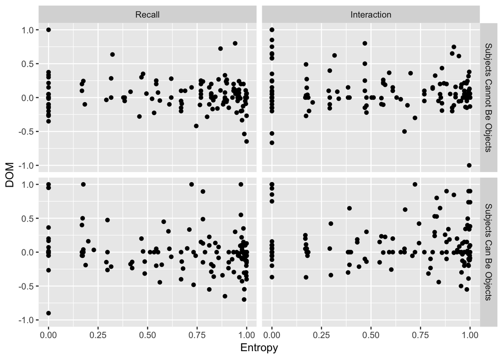

```r
#and plot
ggplot(exp1.to.3.entropy.dom,aes(x=Entropy,y=DOM)) +
  facet_grid(EventType~Block) +
  geom_point()
```

Appropriate stat? Result suggests no significant effect of word order variability on casemarking in either block.

```r
summary(lmer(DOM~Entropy * Block * EventType + (1 | workerId), data=exp1.to.3.entropy.dom))
```

```
## Linear mixed model fit by REML ['lmerMod']
## Formula: DOM ~ Entropy * Block * EventType + (1 | workerId)
##    Data: exp1.to.3.entropy.dom
##
## REML criterion at convergence: 65.6
##
## Scaled residuals:
##     Min      1Q  Median      3Q     Max
## -2.8038 -0.3993 -0.0207  0.3622  3.3322
##
## Random effects:
##  Groups   Name        Variance Std.Dev.
##  workerId (Intercept) 0.05084  0.2255
##  Residual             0.02891  0.1700
## Number of obs: 612, groups:  workerId, 312
##
## Fixed effects:
##                                     Estimate Std. Error t value
## (Intercept)                          0.04629    0.02610   1.773
## Entropy                             -0.05316    0.03645  -1.458
## BlockInteraction                     0.05879    0.02412   2.438
## EventType1                           0.02660    0.05221   0.510
## Entropy:BlockInteraction             0.03973    0.03598   1.104
## Entropy:EventType1                  -0.07193    0.07290  -0.987
## BlockInteraction:EventType1         -0.01625    0.04823  -0.337
## Entropy:BlockInteraction:EventType1  0.11491    0.07195   1.597
##
## Correlation of Fixed Effects:
##             (Intr) Entrpy BlckIn EvntT1 Ent:BI En:ET1 BI:ET1
## Entropy     -0.786
## BlckIntrctn -0.522  0.463
## EventType1   0.069 -0.051 -0.056
## Entrpy:BlcI  0.405 -0.509 -0.816  0.052
## Entrpy:EvT1 -0.051  0.021  0.047 -0.786 -0.041
## BlckInt:ET1 -0.056  0.047  0.093 -0.522 -0.068  0.463
## Entr:BI:ET1  0.052 -0.041 -0.068  0.405  0.029 -0.509 -0.816
```

Same stat excluding 0-word-order-entropy individuals.

```r
summary(lmer(DOM~Entropy * Block * EventType + (1 | workerId), data=subset(exp1.to.3.entropy.dom,Entropy>0)))
```

```
## Linear mixed model fit by REML ['lmerMod']
## Formula: DOM ~ Entropy * Block * EventType + (1 | workerId)
##    Data: subset(exp1.to.3.entropy.dom, Entropy > 0)
##
## REML criterion at convergence: 30.9
##
## Scaled residuals:
##      Min       1Q   Median       3Q      Max
## -2.73686 -0.43091 -0.02674  0.37998  2.87254
##
## Random effects:
##  Groups   Name        Variance Std.Dev.
##  workerId (Intercept) 0.04145  0.2036
##  Residual             0.02974  0.1724
## Number of obs: 446, groups:  workerId, 244
##
## Fixed effects:
##                                      Estimate Std. Error t value
## (Intercept)                          0.056272   0.053011   1.062
## Entropy                             -0.065438   0.065430  -1.000
## BlockInteraction                     0.009928   0.057984   0.171
## EventType1                          -0.042391   0.106021  -0.400
## Entropy:BlockInteraction             0.096922   0.072106   1.344
## Entropy:EventType1                  -0.012176   0.130860  -0.093
## BlockInteraction:EventType1          0.038904   0.115968   0.335
## Entropy:BlockInteraction:EventType1  0.055275   0.144213   0.383
##
## Correlation of Fixed Effects:
##             (Intr) Entrpy BlckIn EvntT1 Ent:BI En:ET1 BI:ET1
## Entropy     -0.943
## BlckIntrctn -0.684  0.667
## EventType1  -0.252  0.246  0.156
## Entrpy:BlcI  0.638 -0.667 -0.956 -0.142
## Entrpy:EvT1  0.246 -0.245 -0.152 -0.943  0.139
## BlckInt:ET1  0.156 -0.152 -0.043 -0.684  0.044  0.667
## Entr:BI:ET1 -0.142  0.139  0.044  0.638 -0.050 -0.667 -0.956
```

## Word order variability and casemarking overall

Do participants who vary word order more (i.e. word order is less informative about argument structure) casemark more, irrespective of animacy?

Measure of word order variability: entropy.

Measure of casemarking: % marked objects.

Will look at day 4 and contrast recall and interaction.

```r
#for casemarking
exp1.to.3.casemarking <- aggregate(casemarked~EventType+Day+Block+workerId,data=subset(exp1.to.3.data,Day==4 & (Block=="SentenceTest1" | Block=="Interaction") & grammatical),FUN=mean)


exp1.to.3.casemarking$Block <- revalue(exp1.to.3.casemarking$Block,
                                         c("SentenceTest1"="Recall",
                                           "Interaction"="Interaction"))
exp1.to.3.casemarking$Block <- relevel(exp1.to.3.casemarking$Block,ref="Recall")

#now merge
exp1.to.3.entropy.marking <- merge(exp1.to.3.proportion.sov,exp1.to.3.casemarking,
                               by=c("workerId","EventType","Block"))
```

Looks strikingly like no correspondence in either case.

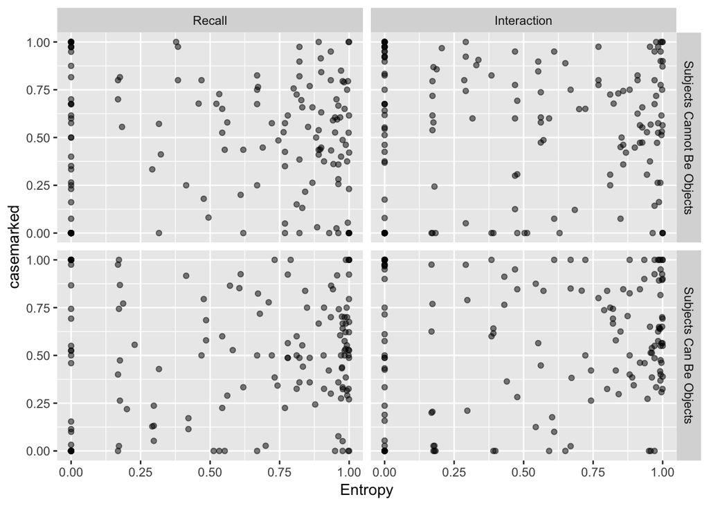

```r
#and plot
ggplot(exp1.to.3.entropy.marking,aes(x=Entropy,y=casemarked)) +
  facet_grid(EventType~Block) +
  geom_point(alpha=0.5)
```

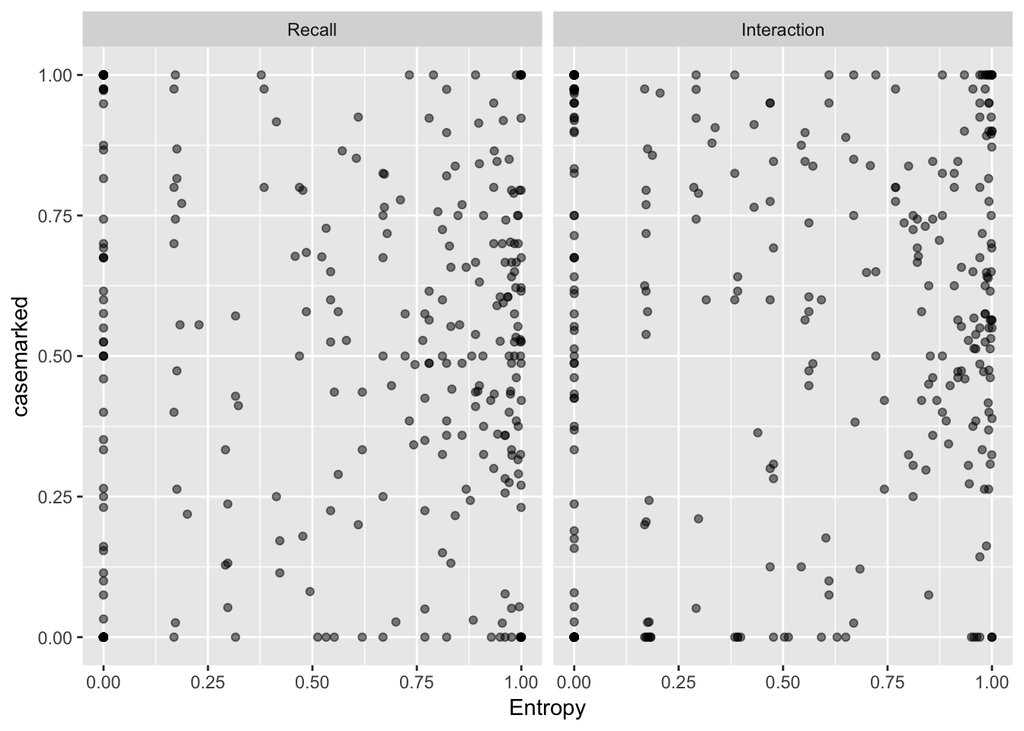

```r
#and plot
ggplot(exp1.to.3.entropy.marking,aes(x=Entropy,y=casemarked)) +
  facet_grid(~Block) +
  geom_point(alpha=0.5)
```

Appropriate stat? Result suggests no significant effect of word order variability on casemarking in either Block.

```r
contrasts(exp1.to.3.entropy.marking$EventType) <- c(-0.5,0.5)
summary(lmer(casemarked~Entropy * Block * EventType + (1 | workerId), data=exp1.to.3.entropy.marking))
```

```
## Linear mixed model fit by REML ['lmerMod']
## Formula: casemarked ~ Entropy * Block * EventType + (1 | workerId)
##    Data: exp1.to.3.entropy.marking
##
## REML criterion at convergence: 145.7
##
## Scaled residuals:
##      Min       1Q   Median       3Q      Max
## -2.92910 -0.44381 -0.03114  0.45136  2.87001
##
## Random effects:
##  Groups   Name        Variance Std.Dev.
##  workerId (Intercept) 0.08797  0.2966
##  Residual             0.02432  0.1559
## Number of obs: 618, groups:  workerId, 314
##
## Fixed effects:
##                                      Estimate Std. Error t value
## (Intercept)                          0.456962   0.028483  16.043
## Entropy                              0.040336   0.038060   1.060
## BlockInteraction                     0.078432   0.021978   3.569
## EventType1                           0.050130   0.056966   0.880
## Entropy:BlockInteraction             0.005004   0.032977   0.152
## Entropy:EventType1                  -0.064499   0.076120  -0.847
## BlockInteraction:EventType1         -0.048178   0.043956  -1.096
## Entropy:BlockInteraction:EventType1  0.073952   0.065954   1.121
##
## Correlation of Fixed Effects:
##             (Intr) Entrpy BlckIn EvntT1 Ent:BI En:ET1 BI:ET1
## Entropy     -0.744
## BlckIntrctn -0.445  0.419
## EventType1   0.062 -0.047 -0.053
## Entrpy:BlcI  0.337 -0.447 -0.815  0.050
## Entrpy:EvT1 -0.047  0.019  0.046 -0.744 -0.043
## BlckInt:ET1 -0.053  0.046  0.099 -0.445 -0.072  0.419
## Entr:BI:ET1  0.050 -0.043 -0.072  0.337  0.031 -0.447 -0.815
```

Same stat excluding 0-word-order-entropy individuals.

```r
summary(lmer(casemarked~Entropy * Block * EventType + (1 | workerId), data=subset(exp1.to.3.entropy.marking,Entropy>0)))
```

```
## Linear mixed model fit by REML ['lmerMod']
## Formula: casemarked ~ Entropy * Block * EventType + (1 | workerId)
##    Data: subset(exp1.to.3.entropy.marking, Entropy > 0)
##
## REML criterion at convergence: 50.2
##
## Scaled residuals:
##      Min       1Q   Median       3Q      Max
## -3.12180 -0.48915 -0.00317  0.45370  3.04427
##
## Random effects:
##  Groups   Name        Variance Std.Dev.
##  workerId (Intercept) 0.06989  0.2644
##  Residual             0.02159  0.1469
## Number of obs: 447, groups:  workerId, 245
##
## Fixed effects:
##                                     Estimate Std. Error t value
## (Intercept)                          0.54505    0.05315  10.255
## Entropy                             -0.06185    0.06474  -0.955
## BlockInteraction                     0.01642    0.05223   0.314
## EventType1                          -0.10080    0.10630  -0.948
## Entropy:BlockInteraction             0.07304    0.06451   1.132
## Entropy:EventType1                   0.12564    0.12947   0.970
## BlockInteraction:EventType1          0.04120    0.10445   0.394
## Entropy:BlockInteraction:EventType1 -0.03081    0.12901  -0.239
##
## Correlation of Fixed Effects:
##             (Intr) Entrpy BlckIn EvntT1 Ent:BI En:ET1 BI:ET1
## Entropy     -0.928
## BlckIntrctn -0.653  0.651
## EventType1  -0.254  0.253  0.147
## Entrpy:BlcI  0.606 -0.640 -0.959 -0.130
## Entrpy:EvT1  0.253 -0.257 -0.146 -0.928  0.130
## BlckInt:ET1  0.147 -0.146 -0.022 -0.653  0.022  0.651
## Entr:BI:ET1 -0.130  0.130  0.022  0.606 -0.027 -0.640 -0.959
```